# Automated download of EU laws with scRapEU

Michele Scotto di Vettimo

2023-07-18

## General information

The following table shows the number of procedures by legal instrument used, status, and decision procedure used:

|  | #Total | Completed | Pending | Rejected | Withdrawn | APP | AVC | CNS | COD | SYN |
| --- | --- | --- | --- | --- | --- | --- | --- | --- | --- | --- |
| leg_instrument |  |  |  |  |  |  |  |  |  |  |
| Decision | 1476 | 1371 | 22 |  | 82 | 9 | 153 | 1007 | 294 | 13 |
| Directive | 1186 | 961 | 94 | 5 | 126 | 3 |  | 293 | 853 | 37 |
| JHA act | 11 | 6 |  |  | 5 |  |  | 11 |  |  |
| Recommendation | 39 | 36 | 1 |  | 2 |  |  | 24 | 13 | 2 |
| Regulation | 2625 | 2238 | 174 |  | 213 | 30 | 11 | 1107 | 1433 | 44 |
| Report | 2 | 2 |  |  |  |  |  | 1 |  | 1 |
| Third Pillar Act | 4 | 4 |  |  |  |  |  | 4 |  |  |
| #Total cases | 5343 | 4618 | 291 | 5 | 428 | 42 | 164 | 2447 | 2593 | 97 |

Note that in all tables if the value reported under “#Total” does not coincide with the number of distinct procedures, it means that there are some missing values on the variables used in the table (see below the section “Information on missing data”).

The table below reports the row percentages, by grouping variable:

|  | Completed | Pending | Rejected | Withdrawn | APP | AVC | CNS | COD | SYN |
| --- | --- | --- | --- | --- | --- | --- | --- | --- | --- |
| leg_instrument |  |  |  |  |  |  |  |  |  |
| Decision | 92.9 | 1.5 |  | 5.6 | 0.6 | 10.4 | 68.2 | 19.9 | 0.9 |
| Directive | 81.0 | 7.9 | 0.4 | 10.6 | 0.3 |  | 24.7 | 71.9 | 3.1 |
| JHA act | 54.5 |  |  | 45.5 |  |  | 100.0 |  |  |
| Recommendation | 92.3 | 2.6 |  | 5.1 |  |  | 61.5 | 33.3 | 5.1 |
| Regulation | 85.3 | 6.6 |  | 8.1 | 1.1 | 0.4 | 42.2 | 54.6 | 1.7 |
| Report | 100.0 |  |  |  |  |  | 50.0 |  | 50.0 |
| Third Pillar Act | 100.0 |  |  |  |  |  | 100.0 |  |  |
| #Total cases | 4618 | 291 | 5 | 428 | 42 | 164 | 2447 | 2593 | 97 |

The figures below show the trend over time of both the usage of a particular decision-making procedure and of the legal instruments:

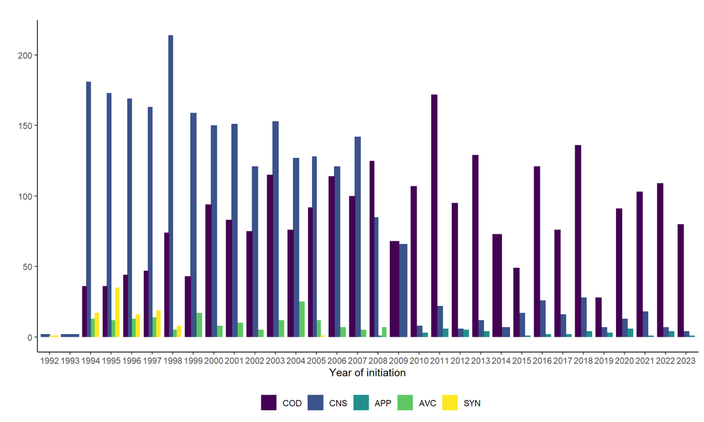

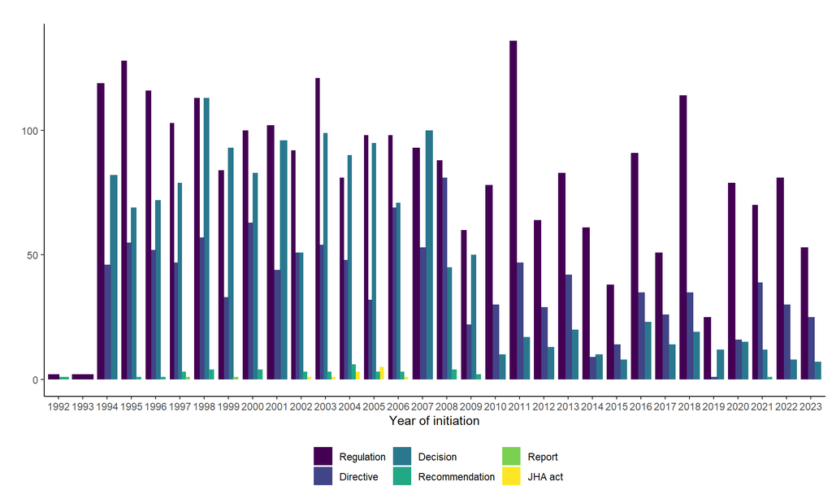

## Textual information extracted

There are 724 procedures for which it has not been possible to retrieve a text of the initiating document. They are distributed across year and legal instrument as follows:

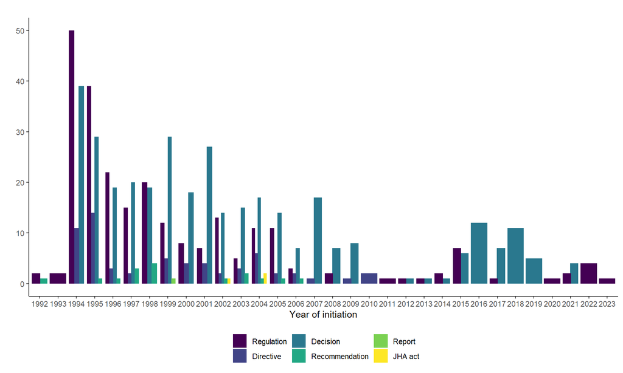

## Information on missing data

This section reports the procedure numbers for which there are missing data on some key variables. First, I estimate the number of procedures that have not been scraped by comparing the number of procedures in the dataset with an handcoded count of procedures by year and procedure type. Then, the section covers the variables for which we do not expect to find missing data. For instance, the legal instrument used or the summary of the final act for adopted proposals. Note that these missing data can be caused by either a poor design of the scraping code (which I will try to address) or by the fact that the information is genuinely not available or ‘’scrapable’’ on the EU websites, in which case it can be manually added by the users if they are able of retrieving it from other sources.

Number of missing procedures (not scraped) is 63.

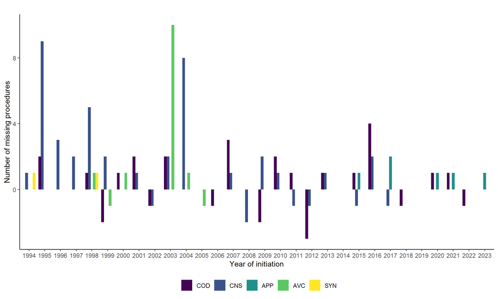

There are 53 procedures (0.98 percent of the total) with missing legal instrument:

```
## 1995/0360(CNS); 1995/0902(CNS); 1996/0902(CNS); 1996/0911(CNS); 1997/0081(CNS); 1997/0227(CNS); 1997/0901(CNS); 1997/0910(CNS); 1997/0911(CNS); 1997/0912(CNS); 1997/0913(CNS); 1997/0914(CNS); 1997/0915(CNS); 1998/0222(CNS); 1998/0902(CNS); 1998/0903(CNS); 1998/0906(CNS); 1998/0909(CNS); 1998/0911…
```

There are 2 procedures (0.04 percent of the total) with missing date of initiation:

```
## 2007/0129(COD); 2014/0033(COD)
```

and 2 procedures (0.04 percent of the total) with missing proposal number:

```
## 2007/0129(COD); 2014/0033(COD)
```

There are 0 procedures (0 percent of the total) with missing OEIL Subject descriptors (useful to identify policy areas).